# Where is the Money for Feminist Organizing? Survey for feminist, women’s rights and gender justice movements, groups and organizations

2024-08-05

#WITM follow up

**Database upload**

```r
# OPEN CSV file
witm <- read.csv2("Data/WITM_csv_last.csv")

source(file="WITM_variables.R")
```

**-.-.-.-.-.-.-.-.-.-.-.-.-.-.-.-.-.-.-.-.-.-.-.-.-.-.-.-.-.-** Section 2: Financial Status **-.-.-.-.-.-.-.-.-.-.-.-.-.-.-.-.-.-.-.-.-.-.-.-.-.-.-.-.-.-**

Q10. What was the annual budget for your group, organization and/or movement in each of the following years in $USD?

Annual_budget

Percentage_2021

Percentage_2022

Percentage_2023

1. Zero budget

15.0

12.7

11.3

2. <5000

17.8

15.6

14.3

3. 5001-10000

12.2

12.5

11.3

4. 10001-30000

13.1

14.8

15.5

5. 30001 -50000

8.4

7.7

8.9

6. 50001 - 100000

9.1

10.9

12.2

7. 100001 - 250000

10.8

10.9

11.4

8. 250001 - 500000

5.5

6.0

6.0

1. 500001 - 1000000

3.1

3.5

3.6

10. 1000001 - 2000000

1.8

2.0

2.1

11. 2000001 - 4000000

1.0

1.2

1.3

12. > 4000001

2.3

2.2

2.1

**–Analysis notes———————————————————————–**

For a better analysis, income should be better grouped.

**————————————————————————————————**

**-.-.-.-.-.-.-.-.-.-.-.-.-.-.-.-.-.-.-.-.-.-.-.-.-.-.-.-.-.-** SECTION : EXTERNAL FOUNDING **-.-.-.-.-.-.-.-.-.-.-.-.-.-.-.-.-.-.-.-.-.-.-.-.-.-.-.-.-.-**

**External founding:**

Q13. Between 2021 and 2023, has your group, organization and/or movement received any external funding?

| External funding | n | porcentaje |
| --- | --- | --- |
| no | 268 | 28.5 |
| yes | 673 | 71.5 |

**–Analysis notes———————————————————————–**

The majority report having external funding but the value of those who do not is very high.

**————————————————————————————————**

**-.-.-.-.-.-.-.-.-.-.-.-.-.-.-.-.-.-.-.-.-.-.-.-.-.-.-.-.-.-**

**External funding by type of organisation**

| q13_ext_funding | Primary focus | Specific Projects | Other |
| --- | --- | --- | --- |
| yes | 73.6 | 63.6 | 70.6 |
| no | 26.4 | 36.4 | 29.4 |

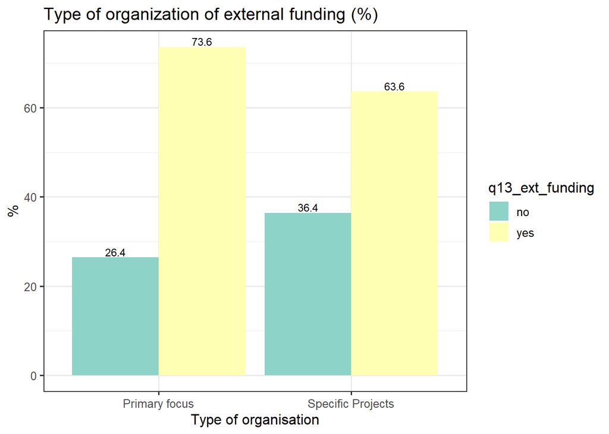

**–Analysis notes———————————————————————–**

Organizations that work on gender and feminist projects receive less external funding.

**————————————————————————————————**

**-.-.-.-.-.-.-.-.-.-.-.-.-.-.-.-.-.-.-.-.-.-.-.-.-.-.-.-.-.-**

**External funding by registration**

| q13_ext_funding | Registered | No registered | Other |
| --- | --- | --- | --- |
| yes | 75.7 | 52.4 | 60 |
| no | 24.3 | 47.6 | 40 |

```
## # A tibble: 6 × 3
## # Groups:   q5_registered [3]
##   q13_ext_funding q5_registered percentage
##   <chr>           <chr>              <dbl>
## 1 yes             Registered          75.7
## 2 no              Registered          24.3
## 3 yes             No registered       52.4
## 4 no              No registered       47.6
## 5 yes             Other               60
## 6 no              Other               40
```

```
## # A tibble: 4 × 3
## # Groups:   q5_registered [2]
##   q13_ext_funding q5_registered percentage
##   <chr>           <chr>              <dbl>
## 1 yes             Registered          75.7
## 2 no              Registered          24.3
## 3 yes             No registered       52.4
## 4 no              No registered       47.6
```

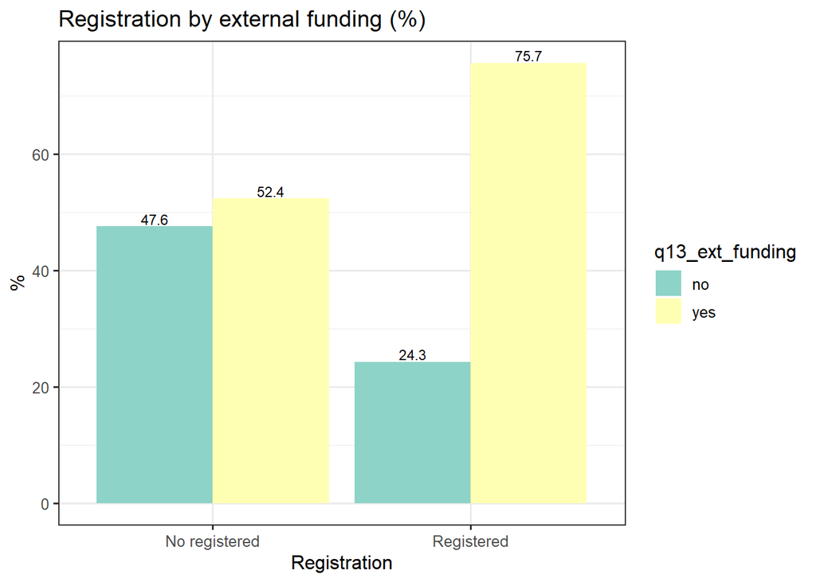

**–Analysis notes———————————————————————–**

Organizations that are not registered receive less frequent external financing

**————————————————————————————————**

**-.-.-.-.-.-.-.-.-.-.-.-.-.-.-.-.-.-.-.-.-.-.-.-.-.-.-.-.-.-**

**External funding by Geographic Scope**

```
## # A tibble: 12 × 3
## # Groups:   q6_geo_scope [6]
##    q13_ext_funding q6_geo_scope                            percentage
##    <chr>           <chr>                                        <dbl>
##  1 yes             Nationally                                    71.7
##  2 yes             Locally                                       66.3
##  3 no              Nationally                                    28.3
##  4 no              Locally                                       33.7
##  5 yes             Regionally                                    86.2
##  6 yes             Global                                        70.7
##  7 no              Global                                        29.3
##  8 yes             Transnationally                               77.8
##  9 no              Regionally                                    13.8
## 10 yes             Work from diaspora, refuge and/or exile       81.8
## 11 no              Transnationally                               22.2
## 12 no              Work from diaspora, refuge and/or exile       18.2
```

| q13_ext_funding | Nationally | Locally | Regionally | Global | Transnationally | Work from diaspora, refuge and/or exile |
| --- | --- | --- | --- | --- | --- | --- |
| yes | 71.7 | 66.3 | 86.2 | 70.7 | 77.8 | 81.8 |
| no | 28.3 | 33.7 | 13.8 | 29.3 | 22.2 | 18.2 |

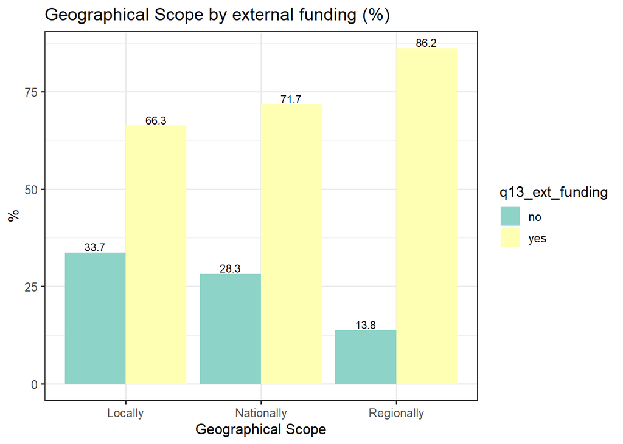

**–Analysis notes———————————————————————–**

This graph is very important and shows how local and national organizations have less access to external funding than regional ones. These groups are taken only because they are numerous, the rest will have to wait for more answers or be analyzed more carefully.

**————————————————————————————————**

**-.-.-.-.-.-.-.-.-.-.-.-.-.-.-.-.-.-.-.-.-.-.-.-.-.-.-.-.-.-**

**External funding by start of activities (year)**

```
## # A tibble: 10 × 3
## # Groups:   q9_year_formation_agrup [5]
##    q13_ext_funding q9_year_formation_agrup percentage
##    <chr>           <chr>                        <dbl>
##  1 yes             (2) From 2015 to 2020         68
##  2 yes             (4) From 2000 to 2009         82.5
##  3 yes             (3) From 2010 to 2014         75.7
##  4 yes             (5) Before 2000               88.3
##  5 no              (2) From 2015 to 2020         32
##  6 no              (1) 2021-2023                 56.6
##  7 yes             (1) 2021-2023                 43.4
##  8 no              (3) From 2010 to 2014         24.3
##  9 no              (4) From 2000 to 2009         17.5
## 10 no              (5) Before 2000               11.7
```

q13_ext_funding

2. From 2015 to 2020
4. From 2000 to 2009
3. From 2010 to 2014
5. Before 2000
1. 2021-2023

yes

68

82.5

75.7

88.3

43.4

no

32

17.5

24.3

11.7

56.6

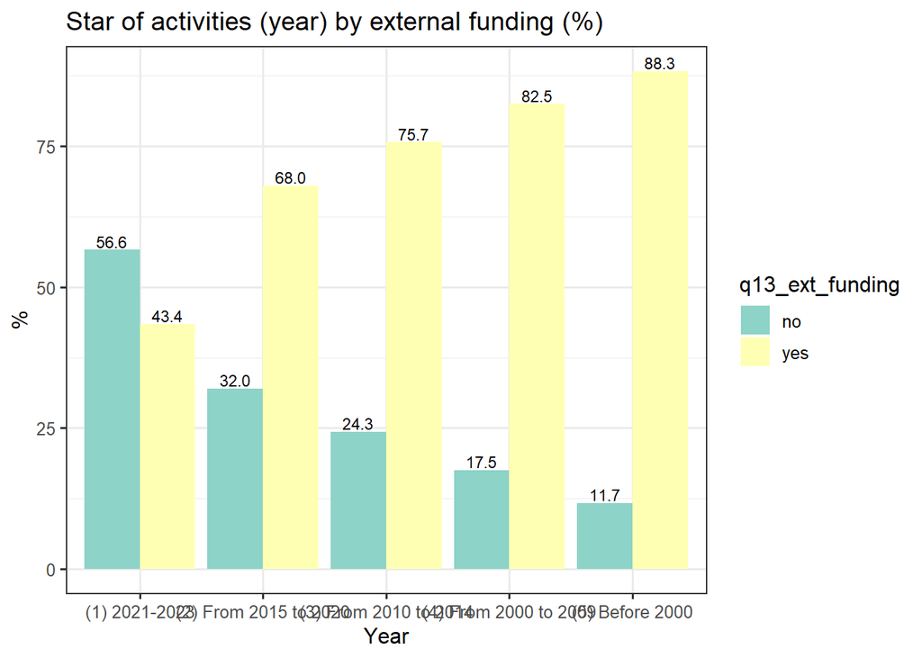

**–Analysis notes———————————————————————–**

As with the registration variable, a progression can be observed. The longer the organization has been in operation, the greater the proportion of organizations with external financing.

**————————————————————————————————**

**-.-.-.-.-.-.-.-.-.-.-.-.-.-.-.-.-.-.-.-.-.-.-.-.-.-.-.-.-.-**

*Q14. Please indicate the percentage of external funding in your total annual budget for each year:

CONDITIONS: [Q14 filtered by Q13= YES]

| Range | Percentage_2023 | Percentage_2022 | Percentage_2021 |
| --- | --- | --- | --- |
| 0 | 2.5 | 6.3 | 11.9 |
| 10 | 6.8 | 6.5 | 8.6 |
| 20 | 4.6 | 7.2 | 6.1 |
| 30 | 6.2 | 5.6 | 5.3 |
| 40 | 5.2 | 5.1 | 4.4 |
| 50 | 4.9 | 5.3 | 5.3 |
| 60 | 5.1 | 4.8 | 5.2 |
| 70 | 7.7 | 8.4 | 6.9 |
| 80 | 12.2 | 9.3 | 7.2 |
| 90 | 16.2 | 16.1 | 15.0 |
| 100 | 28.5 | 25.4 | 24.1 |